# SI 618 - Homework #3: Visualization and Univariate Statistics

### The total score for this assignment will be 100 points, consisting of:

- 10 pt: Overall quality of spelling, grammar, punctuation, etc. of written sentences. ([Guide](https://drive.google.com/file/d/1L0P7xJwjUGBvyb49mL3dw1Bt7hzRTiTl/view))
- 10 pt: Codes are written in [PEP 8](https://www.python.org/dev/peps/pep-0008/) style.
- 80 pt: Homework questions.
- 5 pt: An optional bonus question that is worth up to 5 points.

## Overview

This homework consists of an exploration of a well-known UCI data set about wine quality. The dataset comes from https://www.kaggle.com/uciml/red-wine-quality-cortez-et-al-2009 and you should study the description of the data set before continuing.

## Wine Quality

We get you started by loading some libraries as well as the wine quality dataset:

```python
import pandas as pd
import seaborn as sns
import numpy as np
from scipy import stats
import matplotlib.pyplot as plt
%matplotlib inline
```

```python
wine = pd.read_csv('data/winequality-red.csv')
wine.head()

wine
```

|  | fixed acidity | volatile acidity | citric acid | residual sugar | chlorides | free sulfur dioxide | total sulfur dioxide | density | pH | sulphates | alcohol | quality |
| --- | --- | --- | --- | --- | --- | --- | --- | --- | --- | --- | --- | --- |
| 0 | 7.4 | 0.700 | 0.00 | 1.9 | 0.076 | 11.0 | 34.0 | 0.99780 | 3.51 | 0.56 | 9.4 | 5 |
| 1 | 7.8 | 0.880 | 0.00 | 2.6 | 0.098 | 25.0 | 67.0 | 0.99680 | 3.20 | 0.68 | 9.8 | 5 |
| 2 | 7.8 | 0.760 | 0.04 | 2.3 | 0.092 | 15.0 | 54.0 | 0.99700 | 3.26 | 0.65 | 9.8 | 5 |
| 3 | 11.2 | 0.280 | 0.56 | 1.9 | 0.075 | 17.0 | 60.0 | 0.99800 | 3.16 | 0.58 | 9.8 | 6 |
| 4 | 7.4 | 0.700 | 0.00 | 1.9 | 0.076 | 11.0 | 34.0 | 0.99780 | 3.51 | 0.56 | 9.4 | 5 |
| ... | ... | ... | ... | ... | ... | ... | ... | ... | ... | ... | ... | ... |
| 1594 | 6.2 | 0.600 | 0.08 | 2.0 | 0.090 | 32.0 | 44.0 | 0.99490 | 3.45 | 0.58 | 10.5 | 5 |
| 1595 | 5.9 | 0.550 | 0.10 | 2.2 | 0.062 | 39.0 | 51.0 | 0.99512 | 3.52 | 0.76 | 11.2 | 6 |
| 1596 | 6.3 | 0.510 | 0.13 | 2.3 | 0.076 | 29.0 | 40.0 | 0.99574 | 3.42 | 0.75 | 11.0 | 6 |
| 1597 | 5.9 | 0.645 | 0.12 | 2.0 | 0.075 | 32.0 | 44.0 | 0.99547 | 3.57 | 0.71 | 10.2 | 5 |
| 1598 | 6.0 | 0.310 | 0.47 | 3.6 | 0.067 | 18.0 | 42.0 | 0.99549 | 3.39 | 0.66 | 11.0 | 6 |

1599 rows × 12 columns

## Answer the questions below.

- Write your Python code that can answer the following questions,
- and explain **ALL** your answers in plain English.

```python
MY_UNIQNAME = 'drewpap'
```

### Q1. [5 points] What is the mode of 'quality'?

```python
print(f"\nThe mode of quality is: {stats.mode(wine['quality'])[0][0]}")
```

```
The mode of quality is: 5
```

The mode (most commonly occuring value) of the wine quality value is 5. There was only one mode reported in the stats.mode() results, indicating that this is likely not a multimodal distribution.

### Q2. [15 points] Create a markdown table that contains the mean, median, and standard deviation of each continuous variable (i.e. all numerical variables except for "quality").

```python
wine.loc[:,: "alcohol"].describe().iloc[[1,2,5]]
```

|  | fixed acidity | volatile acidity | citric acid | residual sugar | chlorides | free sulfur dioxide | total sulfur dioxide | density | pH | sulphates | alcohol |
| --- | --- | --- | --- | --- | --- | --- | --- | --- | --- | --- | --- |
| mean | 8.319637 | 0.527821 | 0.270976 | 2.538806 | 0.087467 | 15.874922 | 46.467792 | 0.996747 | 3.311113 | 0.658149 | 10.422983 |
| std | 1.741096 | 0.179060 | 0.194801 | 1.409928 | 0.047065 | 10.460157 | 32.895324 | 0.001887 | 0.154386 | 0.169507 | 1.065668 |
| 50% | 7.900000 | 0.520000 | 0.260000 | 2.200000 | 0.079000 | 14.000000 | 38.000000 | 0.996750 | 3.310000 | 0.620000 | 10.200000 |

Markdown table:

[output not shown]

### Q3. [10 points] Create a histogram that shows the distribution of "fixed acidity". Include a smoothing curve based on a kernel density estimate.

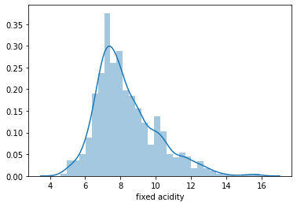

```python
sns.distplot(wine["fixed acidity"], kde = True)
```

To make a histogram of fixed acidity, I used the seaborn .distplot function. I set kde to true to create a smoothing curve overlay atop the histogram.

### Q4. [15 points] Calculate the standard deviation and 95% confidence interval (i.e. the range between the 2.5th and 97.5th percentiles) of "fixed acidity". Use these values to determine to what extent the distribution of "fixed acidity" conforms to the empirical rule (i.e. that 95% of the values fall within 2 standard deviations of the mean).

```python
fixed_acidity_ci = (np.percentile(wine['fixed acidity'],2.5), np.percentile(wine['fixed acidity'],97.5))
fixed_acidity_mean = np.mean(wine['fixed acidity'])
fixed_acidity_std = np.std(wine["fixed acidity"])
two_stdev_fixed_acidity = ((fixed_acidity_mean - (2 * fixed_acidity_std)),(fixed_acidity_mean + (2 * fixed_acidity_std)))

print(f"95% confidence interval: {fixed_acidity_ci}")
print(f"Two standard deviations above and below the mean: {two_stdev_fixed_acidity}")
```

```
95% confidence interval: (5.6, 12.5)
Two standard deviations above and below the mean: (4.838533673075281, 11.800740873516395)
```

The distribution of fixed aciditiy does not conform neatly to the empirical rule. Two standard deviations towards the upward bound lies within the 95% confidence interval, but the lower bound is problematic. Two standard deviations negative of the mean puts the value outside of the confidence interval, which indicates that the estimate of the true population mean may be incorrect given this sample.

### Q5a. [3 points] Create a new column called 'is_good' whose rows should contain the value 'yes' if the value of 'quality' is 6 or more, otherwise it should contain the value 'no'.

```python
wine["is_good"] = np.where(wine["quality"] >= 6, "yes", "no")
wine
```

|  | fixed acidity | volatile acidity | citric acid | residual sugar | chlorides | free sulfur dioxide | total sulfur dioxide | density | pH | sulphates | alcohol | quality | is_good |
| --- | --- | --- | --- | --- | --- | --- | --- | --- | --- | --- | --- | --- | --- |
| 0 | 7.4 | 0.700 | 0.00 | 1.9 | 0.076 | 11.0 | 34.0 | 0.99780 | 3.51 | 0.56 | 9.4 | 5 | no |
| 1 | 7.8 | 0.880 | 0.00 | 2.6 | 0.098 | 25.0 | 67.0 | 0.99680 | 3.20 | 0.68 | 9.8 | 5 | no |
| 2 | 7.8 | 0.760 | 0.04 | 2.3 | 0.092 | 15.0 | 54.0 | 0.99700 | 3.26 | 0.65 | 9.8 | 5 | no |
| 3 | 11.2 | 0.280 | 0.56 | 1.9 | 0.075 | 17.0 | 60.0 | 0.99800 | 3.16 | 0.58 | 9.8 | 6 | yes |
| 4 | 7.4 | 0.700 | 0.00 | 1.9 | 0.076 | 11.0 | 34.0 | 0.99780 | 3.51 | 0.56 | 9.4 | 5 | no |
| ... | ... | ... | ... | ... | ... | ... | ... | ... | ... | ... | ... | ... | ... |
| 1594 | 6.2 | 0.600 | 0.08 | 2.0 | 0.090 | 32.0 | 44.0 | 0.99490 | 3.45 | 0.58 | 10.5 | 5 | no |
| 1595 | 5.9 | 0.550 | 0.10 | 2.2 | 0.062 | 39.0 | 51.0 | 0.99512 | 3.52 | 0.76 | 11.2 | 6 | yes |
| 1596 | 6.3 | 0.510 | 0.13 | 2.3 | 0.076 | 29.0 | 40.0 | 0.99574 | 3.42 | 0.75 | 11.0 | 6 | yes |
| 1597 | 5.9 | 0.645 | 0.12 | 2.0 | 0.075 | 32.0 | 44.0 | 0.99547 | 3.57 | 0.71 | 10.2 | 5 | no |
| 1598 | 6.0 | 0.310 | 0.47 | 3.6 | 0.067 | 18.0 | 42.0 | 0.99549 | 3.39 | 0.66 | 11.0 | 6 | yes |

1599 rows × 13 columns

To create a new column, I used the np.where function that assigns yes to any columns with a quality of 6 or more and no otherwise.

### Q5b. [2 points] Create a new column called 'is_sweet' whose rows should contain the value 'yes' if the value of 'residual sugar' is greater than 3, otherwise it should contain the value 'no'.

```python
wine["is_sweet"] = np.where(wine["residual sugar"] > 3, "yes", "no")
wine
```

|  | fixed acidity | volatile acidity | citric acid | residual sugar | chlorides | free sulfur dioxide | total sulfur dioxide | density | pH | sulphates | alcohol | quality | is_good | is_sweet |
| --- | --- | --- | --- | --- | --- | --- | --- | --- | --- | --- | --- | --- | --- | --- |
| 0 | 7.4 | 0.700 | 0.00 | 1.9 | 0.076 | 11.0 | 34.0 | 0.99780 | 3.51 | 0.56 | 9.4 | 5 | no | no |
| 1 | 7.8 | 0.880 | 0.00 | 2.6 | 0.098 | 25.0 | 67.0 | 0.99680 | 3.20 | 0.68 | 9.8 | 5 | no | no |
| 2 | 7.8 | 0.760 | 0.04 | 2.3 | 0.092 | 15.0 | 54.0 | 0.99700 | 3.26 | 0.65 | 9.8 | 5 | no | no |
| 3 | 11.2 | 0.280 | 0.56 | 1.9 | 0.075 | 17.0 | 60.0 | 0.99800 | 3.16 | 0.58 | 9.8 | 6 | yes | no |
| 4 | 7.4 | 0.700 | 0.00 | 1.9 | 0.076 | 11.0 | 34.0 | 0.99780 | 3.51 | 0.56 | 9.4 | 5 | no | no |
| ... | ... | ... | ... | ... | ... | ... | ... | ... | ... | ... | ... | ... | ... | ... |
| 1594 | 6.2 | 0.600 | 0.08 | 2.0 | 0.090 | 32.0 | 44.0 | 0.99490 | 3.45 | 0.58 | 10.5 | 5 | no | no |
| 1595 | 5.9 | 0.550 | 0.10 | 2.2 | 0.062 | 39.0 | 51.0 | 0.99512 | 3.52 | 0.76 | 11.2 | 6 | yes | no |
| 1596 | 6.3 | 0.510 | 0.13 | 2.3 | 0.076 | 29.0 | 40.0 | 0.99574 | 3.42 | 0.75 | 11.0 | 6 | yes | no |
| 1597 | 5.9 | 0.645 | 0.12 | 2.0 | 0.075 | 32.0 | 44.0 | 0.99547 | 3.57 | 0.71 | 10.2 | 5 | no | no |
| 1598 | 6.0 | 0.310 | 0.47 | 3.6 | 0.067 | 18.0 | 42.0 | 0.99549 | 3.39 | 0.66 | 11.0 | 6 | yes | yes |

1599 rows × 14 columns

### Q6. [10 points] Create the following plot:

[figure not shown]

Provide a meaningful interpretation of the plot.

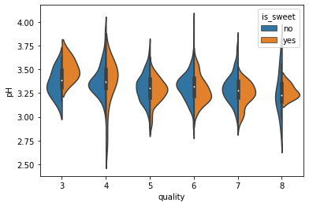

```python
sns.violinplot(wine["quality"],wine["pH"], hue = wine["is_sweet"], split = True)
```

This violin plot visualizes the differences in pH distributions at each quality level. Because the violin plots are split, we can see the differences between sweet and non sweet wines. The most striking change in the plot is the pH distribution of non sweet wines at quality rank 8. There is a wider range of acceptable pH values for non sweet wines at quality rank 8 whereas the pH distribution for sweet wines shrinks.

In general, pH distributions tend to cluster between 3.75 and 2.8 for both non sweet and sweet wines. For sweet wines there does not appear to be much variability in pH across quality levels, except for on the extremes (3 and 8). Non sweet wines, on the other hand, vary more greatly across quality levels.

### Q7. [10 points] Create a pairplot that includes the following variables. Use color to differentiate "good" from "bad" wines, using the "is_good" column.

- 'fixed acidity',
- 'volatile acidity',
- 'citric acid',
- 'residual sugar',
- 'free sulfur dioxide',
- 'pH',
- 'alcohol'

Explain what trends do you notice in good wines? What about bad wines?

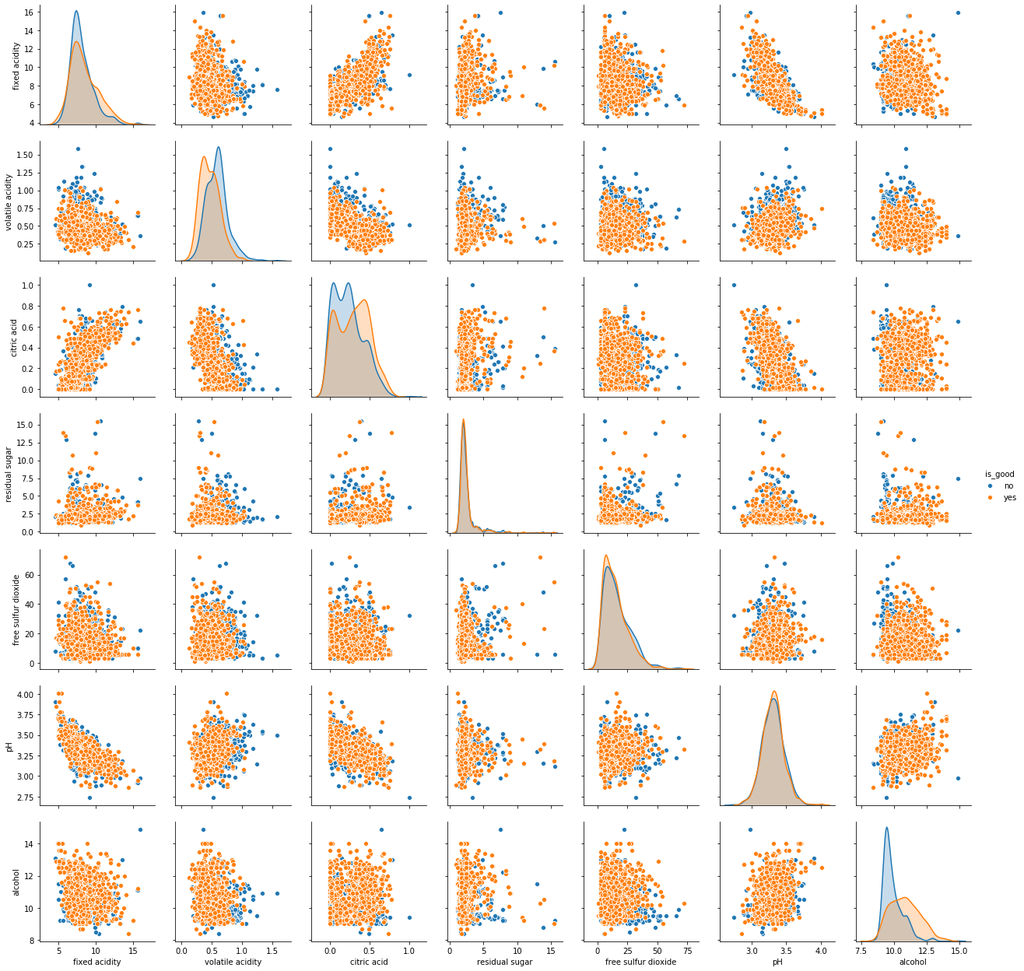

```python
sns.pairplot(data = wine, hue = "is_good",vars = ["fixed acidity",
                                  "volatile acidity",
                                  "citric acid",
                                  "residual sugar",
                                  "free sulfur dioxide",
                                  "pH",
                                  "alcohol"])
```

### Q8. [10 points] Create a scatterplot of 'chlorides' (on the y-axis) vs. 'sulphates' (on the x-axis) and label one interesting point. Use appropriate text and positioning for your annotation.

Explain why you selected that point.

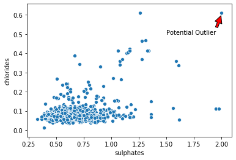

```python
sns.scatterplot(wine["sulphates"], wine["chlorides"])

plt.annotate('Potential Outlier', xy=(2, 0.6), xytext=(1.5, 0.5),
            arrowprops=dict(facecolor='red', shrink=0.05),
            )
plt.show()
```

I selected this point because it deviates greatly from the rest of the group. Points like this ought to be carefully examined. What happened here? Was there an error in measurement? Was this a bad batch of a particular wine? It's important to ask questions about outliers to determine whether or not we should keep them in our data when calculating statistics. A point like this will pull the mean upwards for both sulphates and chlorides and its effect will be exaggerated the smaller our dataset becomes.

### BONUS. [5 points] Plotting Anscombe's quartet

This optional task is to re-create the four plots that comprise Anscombe's quartet. Full points will be awarded to plots that match the figure below **exactly** in terms of all details except for overall size of the image, which can be any reasonable size (i.e. it should be in scale with the notebook).

[figure not shown]

Note that the data is included as part of the Seaborn library, and we have included the code to load the data into a dataframe called anscombe_df:

```python
import seaborn as sns
# Load the example dataset for Anscombe's quartet
anscombe_df = sns.load_dataset("anscombe")
```

```python
# I want to do this but internship interview prep is gonna have to win here
```